# **REKURSIF**

### **Contoh 2: Faktorial Suatu Bilangan**

Faktorial suatu bilangan n(di mana n >= 0) adalah hasil perkalian semua bilangan bulat positif dari 1 hingga n. Untuk menghitung faktorial secara rekursif, kita menghitung faktorial dari ndengan menggunakan faktorial dari (n-1). Kasus dasar untuk fungsi rekursif adalah ketika n = 0, dalam hal ini kita mengembalikan 1.

```python
def fact(n):

    # BASE CONDITION
    if n == 0:
        return 1
    return n * fact(n - 1)

print("Factorial of 5 : ", fact(5))
```

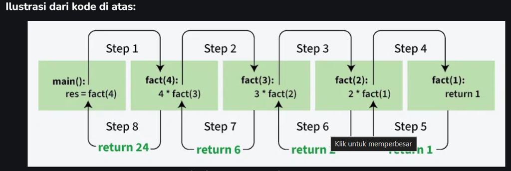

**Kapan kesalahan Stack Overflow terjadi dalam rekursi?**

Jika kondisi dasar tidak tercapai atau tidak didefinisikan, maka masalah stack overflow dapat muncul. Mari kita ambil contoh untuk memahami hal ini.

```python
int fact(int n)
{
    // Kasus dasar yang salah (ini dapat menyebabkan stack overflow).
    if (n == 100)
        return 1;
    else
        return n*fact(n-1);
}
```

- Dalam contoh ini, jika fact(10)dipanggil, fungsi akan memanggil secara rekursif fact(9), kemudian fact(8), fact(7), dan seterusnya. Namun, kasus dasar memeriksa apakah n == 100. Karena ntidak akan pernah mencapai 100 selama panggilan rekursif ini, kasus dasar tidak pernah terpicu. Akibatnya, rekursi berlanjut tanpa batas.
- Rekursi berkelanjutan ini menghabiskan memori pada tumpukan panggilan fungsi. Jika memori sistem habis karena panggilan fungsi yang tak berujung ini, maka akan terjadi kesalahan luapan tumpukan (stack overflow ).
- Untuk mencegah hal ini, sangat penting untuk mendefinisikan kasus dasar yang tepat, misalnya untuk memastikan bahwa rekursi berakhir dan fungsi tidak kehabisan memori.if (n == 0)

**Apa perbedaan antara rekursi langsung dan rekursi tidak langsung?**

Suatu fungsi disebut rekursif langsung jika fungsi tersebut memanggil dirinya sendiri secara langsung selama eksekusinya. Dengan kata lain, fungsi tersebut melakukan panggilan rekursif ke dirinya sendiri di dalam badannya sendiri.

Fungsi rekursif tidak langsung adalah fungsi yang memanggil fungsi lain, dan fungsi lain tersebut, pada gilirannya, memanggil fungsi asli baik secara langsung maupun melalui fungsi lain. Hal ini menciptakan rantai panggilan rekursif yang melibatkan banyak fungsi, berbeda dengan rekursi langsung, di mana sebuah fungsi memanggil dirinya sendiri.

```python
// Contoh rekursi langsung
 void directRecFun()
{
    // Beberapa kode....

    directRecFun();

    // Beberapa kode...
}

// Contoh rekursi tidak langsung
 void indirectRecFun1()
{
    // Beberapa kode...

    indirectRecFun2();

    // Beberapa kode...
}
void indirectRecFun2()
{
    // Beberapa kode...

    indirectRecFun1();

    // Beberapa kode...
}
```

**Apa perbedaan antara rekursi ekor dan rekursi non-ekor?**

Suatu fungsi rekursif disebut rekursif ekor (tail recursive) ketika panggilan rekursif merupakan hal terakhir yang dieksekusi oleh fungsi tersebut.

Silakan lihat rekursi ekor untuk detailnya.

**Bagaimana alokasi memori untuk berbagai panggilan fungsi dalam rekursi?**

Rekursi menggunakan lebih banyak memori untuk menyimpan data setiap panggilan rekursif dalam tumpukan panggilan fungsi internal.

- Setiap kali kita memanggil sebuah fungsi, datanya akan ditambahkan ke dalam stack dan tetap berada di sana hingga panggilan selesai.
- Sistem internal menggunakan stack karena pemanggilan fungsi mengikuti struktur LIFO, yaitu fungsi yang terakhir dipanggil akan selesai lebih dulu.

Ketika suatu fungsi dipanggil dari main(), memori dialokasikan untuk fungsi tersebut di stack. Fungsi rekursif memanggil dirinya sendiri, memori untuk fungsi yang dipanggil dialokasikan di atas memori yang dialokasikan untuk fungsi pemanggil dan salinan variabel lokal yang berbeda dibuat untuk setiap panggilan fungsi. Ketika kasus dasar tercapai, fungsi mengembalikan nilainya ke fungsi yang memanggilnya dan memori dibebaskan dan proses berlanjut. Mari kita ambil contoh bagaimana rekursi bekerja dengan mengambil fungsi sederhana.

```python
# A Python 3 program to
# demonstrate working of
# recursion


def printFun(test):

    if (test < 1):
        return
    else:

        print(test, end=" ")
        printFun(test-1)  # statement 2
        print(test, end=" ")
        return

# Driver Code
test = 3
printFun(test)

# This code is contributed by
# Smitha Dinesh Semwal
```

**Panggilan Awal :** Saat printFun(3)dipanggil dari main(), memori dialokasikan untuk printFun(3). Variabel lokal testdiinisialisasi ke 3, dan pernyataan 1 hingga 4 didorong ke tumpukan.

**Panggilan Rekursif Pertama :**

printFun(3)panggilan printFun(2). Memori printFun(2)dialokasikan, variabel lokal testdiinisialisasi menjadi 2, dan pernyataan 1 hingga 4 dimasukkan ke dalam tumpukan.

**Panggilan Rekursif Kedua :**

printFun(2)panggilan printFun(1). Memori printFun(1)dialokasikan, variabel lokal testdiinisialisasi ke 1, dan pernyataan 1 hingga 4 dimasukkan ke dalam tumpukan.

**Panggilan Rekursif Ketiga :**

printFun(1)panggilan printFun(0). Memori printFun(0)dialokasikan, variabel lokal testdiinisialisasi ke 0, dan pernyataan 1 hingga 4 dimasukkan ke dalam tumpukan.

**Kasus Dasar :** Saat printFun(0)dipanggil, ia akan mencapai kasus dasar (pernyataan if) dan mengembalikan kendali ke printFun(1).

**Kembali dari Rekursi :**

- Setelah kembali dari printFun(0), pernyataan-pernyataan yang tersisa dari printFun(1)dieksekusi dan kendali dikembalikan ke printFun(2).
- Demikian pula, setelah kembali dari printFun(2), kendali kembali ke printFun(3).

**Output :** Hasilnya, output akan mencetak nilai-nilai dalam urutan berikut:

- Dari 3 turun ke 1 (saat panggilan rekursif dilakukan).
- Kemudian dari 1 kembali ke 3 (saat panggilan rekursif terurai).

Tumpukan memori bertambah besar dengan setiap panggilan fungsi dan menyusut saat rekursi berakhir, mengikuti struktur LIFO (Last In, First Out).

**Apa saja keunggulan pemrograman rekursif dibandingkan pemrograman iteratif?**

- Rekursi menyediakan cara yang bersih dan sederhana untuk menulis kode.
- Beberapa masalah pada dasarnya bersifat rekursif, seperti penelusuran pohon , Menara Hanoi , dll. Untuk masalah seperti itu, lebih disukai untuk menulis kode rekursif. Kita juga dapat menulis kode tersebut secara iteratif dengan bantuan struktur data tumpukan (stack). Misalnya, lihat Penelusuran Pohon Inorder tanpa Rekursi , Menara Hanoi Iteratif .

**Apa saja kelemahan pemrograman rekursif dibandingkan pemrograman iteratif?**

Perlu dicatat bahwa setiap program rekursif dapat ditulis secara iteratif dan sebaliknya juga benar.

- Program rekursif biasanya membutuhkan lebih banyak ruang penyimpanan dan juga lebih banyak waktu untuk memelihara tumpukan panggilan rekursi.
- Rekursi dapat membuat kode lebih sulit dipahami dan di-debug, karena membutuhkan pemikiran tentang beberapa tingkatan panggilan fungsi.

**Contoh 3: Fibonacci dengan Rekursi**

Tuliskan program dan relasi rekursi untuk mencari deret Fibonacci dari n di mana n >= 0.

**Persamaan Matematika:**

n jika n == 0, n == 1;  
fib(n) = fib(n-1) + fib(n-2) jika tidak;

**Relasi Rekurensi:**

T(n) = T(n-1) + T(n-2) + O(1)

```python
# Python code to implement Fibonacci series

# Function for fibonacci
def fib(n):

    # Stop condition
    if (n == 0):
        return 0

    # Stop condition
    if (n == 1 or n == 2):
        return 1

    # Recursion function
    else:
        return (fib(n - 1) + fib(n - 2))


# Driver Code

# Initialize variable n.
n = 5;
print("Fibonacci series of 5 numbers is :",end=" ")

# for loop to print the fibonacci series.
for i in range(0,n):
    print(fib(i),end=" ")
```

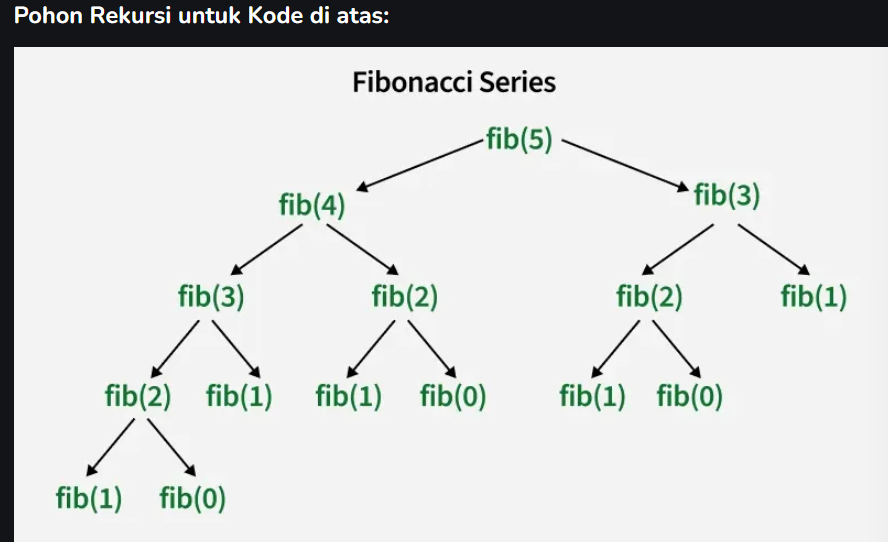

### **Aplikasi Umum Rekursi**

1. Penelusuran Pohon dan Graf : Digunakan untuk menjelajahi simpul/titik sudut secara sistematis dalam struktur data seperti pohon dan graf.
2. Algoritma Pengurutan : Algoritma seperti quicksort dan merge sort membagi data menjadi sub-array, mengurutkannya secara rekursif, dan menggabungkannya.
3. Algoritma Bagi dan Taklukkan : Algoritma seperti pencarian biner memecah masalah menjadi submasalah yang lebih kecil menggunakan rekursi.
4. Pembentukan Fraktal : Rekursi membantu menghasilkan pola fraktal, seperti himpunan Mandelbrot, dengan menerapkan rumus rekursif secara berulang.
5. Algoritma Backtracking : Digunakan untuk masalah yang membutuhkan serangkaian keputusan, di mana rekursi mengeksplorasi semua jalur yang mungkin dan melakukan backtracking bila diperlukan.
6. Memoisasi : Melibatkan penyimpanan hasil panggilan fungsi rekursif untuk menghindari penghitungan ulang submasalah yang mahal.
7. Ini hanyalah beberapa contoh dari banyak aplikasi rekursi dalam ilmu komputer dan pemrograman. Rekursi adalah alat yang serbaguna dan ampuh yang dapat digunakan untuk menyelesaikan berbagai jenis masalah.

**Ringkasan Rekursi:**

- Dalam rekursi terdapat dua jenis kasus, yaitu kasus rekursif dan kasus dasar.
- Kasus dasar digunakan untuk menghentikan fungsi rekursif ketika kasus tersebut ternyata benar.
- Setiap panggilan rekursif membuat salinan baru dari metode tersebut di memori tumpukan.
- Rekursi tak terbatas dapat menyebabkan kehabisan memori tumpukan (stack memory).
- Contoh algoritma rekursif: Merge Sort, Quick Sort , Menara Hanoi , Deret Fibonacci , Masalah Faktorial , dll.

## **LATIHAN PILGAN**

**1. Apa syarat mutlak yang harus dimiliki oleh fungsi rekursif agar tidak terjadi infinite loop?**

A. Memiliki perulangan for

B. Memiliki Base Case (kondisi berhenti)

C. Memiliki variabel global

D. Memiliki nilai return berupa list

Jawaban: B (Memiliki Base Case)

**2. Apa yang terjadi jika sebuah fungsi rekursif tidak memiliki base case?**

A. Program berjalan lebih cepat

B. Terjadi Stack Overflow karena pemanggilan fungsi yang tidak terbatas

C. Program secara otomatis berhenti setelah 10 detik

D. Program mengembalikan nilai 0

Jawaban: B (Terjadi Stack Overflow)

**3. Manakah dari masalah berikut yang paling tepat diselesaikan menggunakan rekursif?**

A. Menghitung rata-rata nilai dalam sebuah list

B. Mengurutkan array dengan Bubble Sort

C. Menghitung faktorial dari sebuah bilangan $n$

D. Mencetak input user

Jawaban: C (Menghitung faktorial dari sebuah bilangan $n$)

**4. Jika fungsi f(n) didefinisikan sebagai f(n) = f(n-1) + 2 dengan f(1) = 3, berapakah nilai f(3)?**

A. 5

B. 7

C. 9

D. 3

Jawaban: B (7) Penjelasan: f(1)=3, f(2)=3+2=5, f(3)=5+2=7.

**5. Apa perbedaan utama antara perulangan (iterasi) dan rekursif?**

A. Rekursif selalu lebih cepat daripada perulangan

B. Rekursif menggunakan Call Stack, sedangkan perulangan menggunakan variabel kontrol

C. Rekursif hanya bisa digunakan untuk bahasa Python

D. Perulangan tidak bisa menghitung faktorial

Jawaban: B (Rekursif menggunakan Call Stack, sedangkan perulangan menggunakan variabel kontrol)

# **LATIHAN CODE**

**Soal 1: Faktorial Rekursif Instruksi: Buatlah fungsi rekursif untuk menghitung faktorial dari bilangan n (n! = n * (n-1)!)**

```python
def faktorial(n):
    # Base case
    if n == 1 or n == 0:
        return 1
    # Rekursif case
    else:
        return n * faktorial(n - 1)

print(f"Faktorial 5 adalah: {faktorial(5)}")
```

**Soal 2: Deret Fibonacci Rekursif Instruksi: Buatlah fungsi rekursif untuk mencari nilai Fibonacci ke-n (0, 1, 1, 2, 3, 5, ...).**

```python
def fibonacci(n):
    if n <= 1:
        return n
    else:
        return fibonacci(n-1) + fibonacci(n-2)

print(f"Fibonacci ke-6 adalah: {fibonacci(6)}")
```

**Soal 3: Penjumlahan List Rekursif Instruksi: Buatlah fungsi rekursif untuk menjumlahkan seluruh angka di dalam sebuah list tanpa menggunakan perulangan.**

```python
def jumlah_list(data):
    if not data:
        return 0
    else:
        return data[0] + jumlah_list(data[1:])

angka = [1, 2, 3, 4, 5]
print(f"Total list: {jumlah_list(angka)}")
```

**Soal 4: Menghitung Pangkat Rekursif Instruksi: Buatlah fungsi rekursif untuk menghitung hasil dari basis pangkat eksponen (misal: 2^3 = 8).**

```python
def pangkat(basis, eksponen):
    if eksponen == 0:
        return 1
    else:
        return basis * pangkat(basis, eksponen - 1)

print(f"2 pangkat 3 adalah: {pangkat(2, 3)}")
```

**Soal 5: Membalik String secara Rekursif Instruksi: Buatlah fungsi rekursif untuk membalikkan posisi karakter dalam sebuah string (contoh: "Zaka" -> "akaZ").**

```python
def balik_string(s):
    if len(s) == 0:
        return s
    else:
        return balik_string(s[1:]) + s[0]

print(f"Hasil balik: {balik_string('Zaka')}")
```

**Soal 6: Cek Palindrom dengan Rekursif Instruksi: Buatlah fungsi rekursif untuk mengecek apakah sebuah string adalah palindrom (dibaca depan-belakang sama).**

```python
def is_palindrom(s):
    if len(s) <= 1:
        return True
    if s[0] == s[-1]:
        return is_palindrom(s[1:-1])
    else:
        return False

print(f"Apakah 'katak' palindrom? {is_palindrom('katak')}")
```

**Soal 7: Menghitung Jumlah Digit Angka Instruksi: Buatlah fungsi rekursif untuk menghitung jumlah total digit dari sebuah bilangan integer (contoh: 123 -> 1+2+3 = 6).**

```python
def jumlah_digit(n):
    if n == 0:
        return 0
    else:
        return (n % 10) + jumlah_digit(n // 10)

print(f"Jumlah digit 123 adalah: {jumlah_digit(123)}")
```

**Soal 8: Konversi Desimal ke Biner (Rekursif) Instruksi: Buatlah fungsi rekursif untuk mengubah angka desimal menjadi string biner.**

```python
def desimal_ke_biner(n):
    if n > 1:
        return desimal_ke_biner(n // 2) + str(n % 2)
    return str(n % 2)

print(f"Biner dari 10 adalah: {desimal_ke_biner(10)}")
```

**Soal 9: Pencarian Rekursif (Binary Search) Instruksi: Buatlah fungsi rekursif untuk mencari posisi indeks sebuah target angka dalam list yang sudah terurut.**

```python
def binary_search(arr, low, high, target):
    if high >= low:
        mid = (high + low) // 2
        if arr[mid] == target:
            return mid
        elif arr[mid] > target:
            return binary_search(arr, low, mid - 1, target)
        else:
            return binary_search(arr, mid + 1, high, target)
    return -1

data = [1, 2, 3, 4, 5]
print(f"Indeks target 3: {binary_search(data, 0, len(data)-1, 3)}")
```

**Soal 10: Mencari Nilai Maksimum Rekursif Instruksi: Buatlah fungsi rekursif untuk menemukan angka terbesar dalam sebuah list tanpa menggunakan fungsi max().**

```python
def find_max(arr):
    if len(arr) == 1:
        return arr[0]
    else:
        sub_max = find_max(arr[1:])
        return arr[0] if arr[0] > sub_max else sub_max

data = [10, 5, 20, 8, 15]
print(f"Angka maksimal: {find_max(data)}")
```